# Lab 6

## EECS 738 Lab 6

### Step 0: Import required packages

```python
from __future__ import print_function

import os
import sys
import csv

import pandas as pd
import numpy as np
import matplotlib.pyplot as plt

import tensorflow as tf
from tensorflow import keras
from tensorflow.keras.models import Sequential
from tensorflow.keras.layers import *
from tensorflow.keras.activations import relu
from tensorflow.keras.preprocessing import sequence
from tensorflow.keras.preprocessing.sequence import pad_sequences
from tensorflow.keras import backend as K

from tensorflow.keras.datasets import imdb

from IPython.core.interactiveshell import InteractiveShell
InteractiveShell.ast_node_interactivity = "all"

print(os.getcwd())
print("Modules imported \n")
print("Files in current directory:")
from subprocess import check_output
#print(check_output(["ls", "../data"]).decode("utf8")) #check the files available in the directory

print("Packages Loaded")
print('The Tensorflow version is {}.'.format(tf.__version__))
print('The Keras version is {}.'.format(keras.__version__))
print('The Pandas version is {}.'.format(pd.__version__))
print('The Numpy version is {}.'.format(np.__version__))
print(np.__file__)
```

```
C:\Users\pmspr\Documents\HS\MS\Sem 2\EECS 738\Lab\6
Modules imported

Files in current directory:
Packages Loaded
The Tensorflow version is 2.1.0.
The Keras version is 2.2.4-tf.
The Pandas version is 1.0.3.
The Numpy version is 1.18.1.
C:\ProgramData\Anaconda2\envs\TFK35\lib\site-packages\numpy\__init__.py
```

I wanted to use a more complex dataset for this but the time constraints due to COV-19 have made that difficult.

So now lets get into the data we are working with today. In the last couple of labs we used CNNs and ResNets a lot. This time we are going to compare CNNs with LSTMs for the purpose of classifying text. The data is setup so that a '0 label' is a negative review and a '1 label' is a postive review.

We want to create machine learning models to automatically detect whether or not a review is positive. This has wide applications for both industry and research and has been extensively researched since 2014.

### Step 1: Load Imdb dataset

```python
# Lets load our data. We will limit the number of words to 5,000 as that is how the data is setup.
(x_train, y_train), (x_test, y_test) = imdb.load_data(num_words=2500)

print("train_data ", x_train.shape)
print("train_labels ", y_train.shape)
print("_"*100)
print("test_data ", x_test.shape)
print("test_labels ", y_test.shape)
print("_"*100)
print("Maximum value of a word index ")
print(max([max(sequence) for sequence in x_train]))
print("Maximum length num words of review in train ")
print(max([len(sequence) for sequence in x_train]))

# See an actual review in words
# Reverse from integers to words using the DICTIONARY (given by keras...need to do nothing to create it)

word_index = imdb.get_word_index()

reverse_word_index = dict(
[(value, key) for (key, value) in word_index.items()])

decoded_review = ' '.join(
[reverse_word_index.get(i - 0, '?') for i in x_train[1]])

#print(x_train[1])
print(decoded_review)
```

```
train_data  (25000,)
train_labels  (25000,)
____________________________________________________________________________________________________
test_data  (25000,)
test_labels  (25000,)
____________________________________________________________________________________________________
Maximum value of a word index
2499
Maximum length num words of review in train
2494
the thought solid thought and do making to is spot and and while he of jack in where picked as getting on was did hands fact characters to always life and not as me can't in at are br of sure your way of little it strongly random to view of love it so and of guy it used producer of where it of here …
```

### Step 2: Pad train and test data.

```python
# We pad the data because not all sentences in our data are the same length. We want to use a number that is larger than our largest data. Here I will choose 400.
x_train = sequence.pad_sequences(x_train, maxlen=400)
x_test = sequence.pad_sequences(x_test, maxlen=400)
```

### Step 3: Create a 1D CNN for baseline.

```
Train on 22500 samples, validate on 2500 samples
```

```
(0, 1)
```

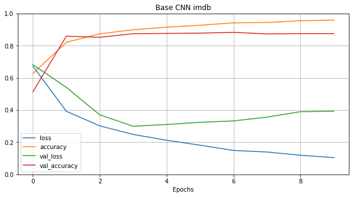

```
[0.3916378186559677, 0.87404]
```

```
Model: "sequential_5"
_________________________________________________________________
Layer (type)                 Output Shape              Param #
=================================================================
embedding_5 (Embedding)      (None, 400, 50)           125000
_________________________________________________________________
dropout_10 (Dropout)         (None, 400, 50)           0
_________________________________________________________________
conv1d_10 (Conv1D)           (None, 398, 64)           9664
_________________________________________________________________
batch_normalization_10 (Batc (None, 398, 64)           256
_________________________________________________________________
conv1d_11 (Conv1D)           (None, 396, 64)           12352
_________________________________________________________________
batch_normalization_11 (Batc (None, 396, 64)           256
_________________________________________________________________
global_max_pooling1d_5 (Glob (None, 64)                0
_________________________________________________________________
dense_10 (Dense)             (None, 512)               33280
_________________________________________________________________
dropout_11 (Dropout)         (None, 512)               0
_________________________________________________________________
activation_10 (Activation)   (None, 512)               0
_________________________________________________________________
dense_11 (Dense)             (None, 1)                 513
_________________________________________________________________
activation_11 (Activation)   (None, 1)                 0
=================================================================
Total params: 181,321
Trainable params: 181,065
Non-trainable params: 256
_________________________________________________________________
```

```python
# Lets start with a very simple 1D CNN model. We will use this as our baseline for everything else in this lab.
model = Sequential()

# This embedding is a trainable parameter. We aren't using GloVE for this model.
model.add(keras.layers.Embedding(2500,50,input_length=400))
model.add(keras.layers.Dropout(0.2))

# There isn't much of a difference with how 1D and 2D CNNs work. They still use filters and scan the data.
# we will use a similar model as our 2D CNN with the adition of an embedding layer at the beginning.
model.add(keras.layers.Conv1D(64,3,padding='valid',activation='relu',strides=1))
model.add(keras.layers.BatchNormalization())
model.add(keras.layers.Conv1D(64,3,padding='valid',activation='relu',strides=1))
model.add(keras.layers.BatchNormalization())
model.add(keras.layers.GlobalMaxPooling1D())

model.add(keras.layers.Dense(512))
model.add(keras.layers.Dropout(0.5))
model.add(keras.layers.Activation('relu'))

# We will use a sigmoid and a 1 neuron dense output since our data is binary.
model.add(keras.layers.Dense(1))
model.add(keras.layers.Activation('sigmoid'))

model.compile(loss='binary_crossentropy',
              optimizer='Nadam',
              metrics=['accuracy'])

history = model.fit(x_train, y_train,
              batch_size=128,
              epochs=10,
              validation_split=0.1)

history = pd.DataFrame(history.history)
history.plot(figsize=(10,5))
plt.grid(True)
plt.gca().set_ylim(0,1)
plt.xlabel('Epochs')
plt.title('Base CNN imdb')
plt.show()

#After training the model, evaluate the test set
model.evaluate(x_test,y_test)

#Print the summary of the model
model.summary()
```

### Step 5: Filters change from 64 to 250

```
Train on 22500 samples, validate on 2500 samples
```

```
(0, 1)
```

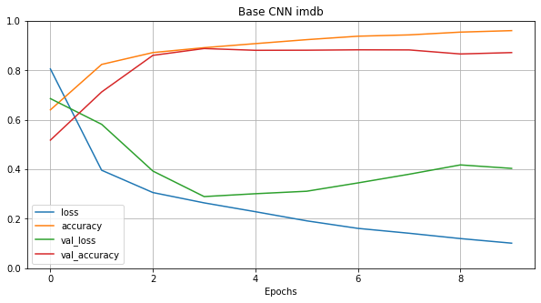

```
[0.3617532423210144, 0.88028]
```

```
Model: "sequential_6"
_________________________________________________________________
Layer (type)                 Output Shape              Param #
=================================================================
embedding_6 (Embedding)      (None, 400, 50)           125000
_________________________________________________________________
dropout_12 (Dropout)         (None, 400, 50)           0
_________________________________________________________________
conv1d_12 (Conv1D)           (None, 398, 250)          37750
_________________________________________________________________
batch_normalization_12 (Batc (None, 398, 250)          1000
_________________________________________________________________
conv1d_13 (Conv1D)           (None, 396, 250)          187750
_________________________________________________________________
batch_normalization_13 (Batc (None, 396, 250)          1000
_________________________________________________________________
global_max_pooling1d_6 (Glob (None, 250)               0
_________________________________________________________________
dense_12 (Dense)             (None, 512)               128512
_________________________________________________________________
dropout_13 (Dropout)         (None, 512)               0
_________________________________________________________________
activation_12 (Activation)   (None, 512)               0
_________________________________________________________________
dense_13 (Dense)             (None, 1)                 513
_________________________________________________________________
activation_13 (Activation)   (None, 1)                 0
=================================================================
Total params: 481,525
Trainable params: 480,525
Non-trainable params: 1,000
_________________________________________________________________
```

```python
# Now we will make the network more complex by adding more filters to the data. How did this affect training?
# Lets start with a very simple 1D CNN model. We will use this as our baseline for everything else in this lab.
model = Sequential()

# This embedding is a trainable parameter. We aren't using GloVE for this model.
model.add(keras.layers.Embedding(2500,50,input_length=400))
model.add(keras.layers.Dropout(0.2))

# There isn't much of a difference with how 1D and 2D CNNs work. They still use filters and scan the data.
# we will use a similar model as our 2D CNN with the adition of an embedding layer at the beginning.
model.add(keras.layers.Conv1D(250,3,padding='valid',activation='relu',strides=1))
model.add(keras.layers.BatchNormalization())
model.add(keras.layers.Conv1D(250,3,padding='valid',activation='relu',strides=1))
model.add(keras.layers.BatchNormalization())
model.add(keras.layers.GlobalMaxPooling1D())

model.add(keras.layers.Dense(512))
model.add(keras.layers.Dropout(0.5))
model.add(keras.layers.Activation('relu'))

# We will use a sigmoid and a 1 neuron dense output since our data is binary.
model.add(keras.layers.Dense(1))
model.add(keras.layers.Activation('sigmoid'))

model.compile(loss='binary_crossentropy',
              optimizer='Nadam',
              metrics=['accuracy'])

history = model.fit(x_train, y_train,
              batch_size=128,
              epochs=10,
              validation_split=0.1)

history = pd.DataFrame(history.history)
history.plot(figsize=(10,5))
plt.grid(True)
plt.gca().set_ylim(0,1)
plt.xlabel('Epochs')
plt.title('Base CNN imdb')
plt.show()

#After training the model, evaluate the test set
model.evaluate(x_test,y_test)

#Print the summary of the model
model.summary()
```

Analysis:

- Changing filters from 64 to 250, did not contribute much in improving the accuracies. Training and validation accuracies remained same for the dataset of 2500. On the contrary, training speed is increased.

### Step 6: Add pair of CNN and normalization layers

```
Train on 22500 samples, validate on 2500 samples
```

```
(0, 1)
```

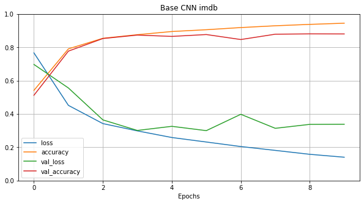

```
[0.3555895343375206, 0.87204]
```

```
Model: "sequential_9"
_________________________________________________________________
Layer (type)                 Output Shape              Param #
=================================================================
embedding_9 (Embedding)      (None, 400, 50)           125000
_________________________________________________________________
dropout_17 (Dropout)         (None, 400, 50)           0
_________________________________________________________________
conv1d_20 (Conv1D)           (None, 398, 64)           9664
_________________________________________________________________
batch_normalization_18 (Batc (None, 398, 64)           256
_________________________________________________________________
conv1d_21 (Conv1D)           (None, 396, 64)           12352
_________________________________________________________________
batch_normalization_19 (Batc (None, 396, 64)           256
_________________________________________________________________
dense_15 (Dense)             (None, 396, 512)          33280
_________________________________________________________________
dropout_18 (Dropout)         (None, 396, 512)          0
_________________________________________________________________
activation_15 (Activation)   (None, 396, 512)          0
_________________________________________________________________
conv1d_22 (Conv1D)           (None, 394, 64)           98368
_________________________________________________________________
batch_normalization_20 (Batc (None, 394, 64)           256
_________________________________________________________________
conv1d_23 (Conv1D)           (None, 392, 64)           12352
_________________________________________________________________
batch_normalization_21 (Batc (None, 392, 64)           256
_________________________________________________________________
global_max_pooling1d_9 (Glob (None, 64)                0
_________________________________________________________________
dense_16 (Dense)             (None, 512)               33280
_________________________________________________________________
dropout_19 (Dropout)         (None, 512)               0
_________________________________________________________________
activation_16 (Activation)   (None, 512)               0
_________________________________________________________________
dense_17 (Dense)             (None, 1)                 513
_________________________________________________________________
activation_17 (Activation)   (None, 1)                 0
=================================================================
Total params: 325,833
Trainable params: 325,321
Non-trainable params: 512
_________________________________________________________________
```

```python
# Now lets add more CNN and BatchNorm layers to the network. Did this have the same affect as 2D CNNs from lab 5?
# Lets start with a very simple 1D CNN model. We will use this as our baseline for everything else in this lab.
model = Sequential()

# This embedding is a trainable parameter. We aren't using GloVE for this model.
model.add(keras.layers.Embedding(2500,50,input_length=400))
model.add(keras.layers.Dropout(0.2))

# There isn't much of a difference with how 1D and 2D CNNs work. They still use filters and scan the data.
# we will use a similar model as our 2D CNN with the adition of an embedding layer at the beginning.
model.add(keras.layers.Conv1D(64,3,padding='valid',activation='relu',strides=1))
model.add(keras.layers.BatchNormalization())
model.add(keras.layers.Conv1D(64,3,padding='valid',activation='relu',strides=1))
model.add(keras.layers.BatchNormalization())

model.add(keras.layers.Dense(512))
model.add(keras.layers.Dropout(0.5))
model.add(keras.layers.Activation('relu'))

model.add(keras.layers.Conv1D(64,3,padding='valid',activation='relu',strides=1))
model.add(keras.layers.BatchNormalization())
model.add(keras.layers.Conv1D(64,3,padding='valid',activation='relu',strides=1))
model.add(keras.layers.BatchNormalization())
model.add(keras.layers.GlobalMaxPooling1D())

model.add(keras.layers.Dense(512))
model.add(keras.layers.Dropout(0.5))
model.add(keras.layers.Activation('relu'))

# We will use a sigmoid and a 1 neuron dense output since our data is binary.
model.add(keras.layers.Dense(1))
model.add(keras.layers.Activation('sigmoid'))

model.compile(loss='binary_crossentropy',
              optimizer='Nadam',
              metrics=['accuracy'])

history = model.fit(x_train, y_train,
              batch_size=128,
              epochs=10,
              validation_split=0.1)

history = pd.DataFrame(history.history)
history.plot(figsize=(10,5))
plt.grid(True)
plt.gca().set_ylim(0,1)
plt.xlabel('Epochs')
plt.title('Base CNN imdb')
plt.show()

#After training the model, evaluate the test set
model.evaluate(x_test,y_test)

#Print the summary of the model
model.summary()
```

#### Do 1D CNNs and 2D CNNs behave the same from the changes we are making?

Now lets look at some LSTMs. LSTMs and RNNs in general were the racehorse of deep learning from 2014-2016. Now they have drastically fallen off of favor in the DL community. The questions we want to answer in this lab are: Why do you think this is? Do you think it was a mistake to stray away from RNNs? What changes do you think we could make to make them better or should we just drop them all together?

The resources to learn more about this debate can be found here: https://towardsdatascience.com/the-fall-of-rnn-lstm-2d1594c74ce0

and here: https://towardsdatascience.com/memory-attention-sequences-37456d271992

and here: https://towardsdatascience.com/visual-attention-model-in-deep-learning-708813c2912c

These are optional readings but they serve to give you a firm foundation on the knowledge of current deep learning thought. Feel free to answer the above questions after we train our LSTMs.

If you don't know anything about RNNs read this: http://karpathy.github.io/2015/05/21/rnn-effectiveness/

### Step 7: LSTM model

```
Train on 25000 samples, validate on 25000 samples
```

```
(0, 1)
```

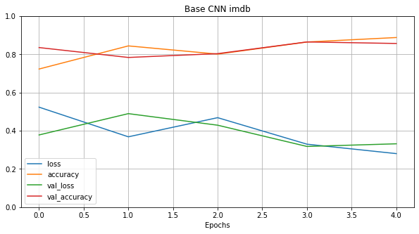

```
[0.3317405798149109, 0.85704]
```

```
Model: "sequential_11"
_________________________________________________________________
Layer (type)                 Output Shape              Param #
=================================================================
embedding_11 (Embedding)     (None, 400, 50)           250000
_________________________________________________________________
lstm_2 (LSTM)                (None, 400, 128)          91648
_________________________________________________________________
lstm_3 (LSTM)                (None, 128)               131584
_________________________________________________________________
dense_20 (Dense)             (None, 512)               66048
_________________________________________________________________
dropout_21 (Dropout)         (None, 512)               0
_________________________________________________________________
dense_21 (Dense)             (None, 1)                 513
=================================================================
Total params: 539,793
Trainable params: 539,793
Non-trainable params: 0
_________________________________________________________________
```

```python
# Now we will make our LSTMs. We will use a smaller batch size as they take longer to train.
# We use the same embedding layers as we did for our CNNs.
model = keras.models.Sequential()
model.add(keras.layers.Embedding(5000,50,input_length=400))

# Here we will add in our LSTM layers. They should be directly after the embedding layer.
model.add(keras.layers.LSTM(128, return_sequences=True))
model.add(keras.layers.LSTM(128))

# Now we will cast the LSTM output to a dense layer to sort it. If you haven't noticed, thick dense layers at the end of networks are how every model 'collects its thoughts'.
model.add(keras.layers.Dense(512, activation='relu'))
model.add(keras.layers.Dropout(0.5))
model.add(keras.layers.Dense(1, activation='sigmoid'))

model.compile('Nadam', 'binary_crossentropy', metrics=['accuracy'])

history = model.fit(x_train, y_train,
              batch_size=128,
              epochs=5,
              validation_data=[x_test, y_test])

history = pd.DataFrame(history.history)
history.plot(figsize=(10,5))
plt.grid(True)
plt.gca().set_ylim(0,1)
plt.xlabel('Epochs')
plt.title('Base CNN imdb')
plt.show()

#After training the model, evaluate the test set
model.evaluate(x_test,y_test)

#Print the summary of the model
model.summary()
```

### Step 8: LSTM - 2 layers

```python
# Now lets add another LSTM layer to our model. Did that improve overfitting/accuracy?
model = keras.models.Sequential()
model.add(keras.layers.Embedding(5000,50,input_length=400))

# Here we will add in our LSTM layers. They should be directly after the embedding layer.
model.add(keras.layers.LSTM(128, return_sequences=True))
model.add(keras.layers.LSTM(128, return_sequences=True)) ## Added layer
model.add(keras.layers.LSTM(128))

# Now we will cast the LSTM output to a dense layer to sort it. If you haven't noticed, thick dense layers at the end of networks are how every model 'collects its thoughts'.
model.add(keras.layers.Dense(512, activation='relu'))
model.add(keras.layers.Dropout(0.5))
model.add(keras.layers.Dense(1, activation='sigmoid'))

model.compile('Nadam', 'binary_crossentropy', metrics=['accuracy'])

history = model.fit(x_train, y_train,
              batch_size=128,
              epochs=5,
              validation_data=[x_test, y_test])

history = pd.DataFrame(history.history)
history.plot(figsize=(10,5))
plt.grid(True)
plt.gca().set_ylim(0,1)
plt.xlabel('Epochs')
plt.title('Base CNN imdb')
plt.show()

#After training the model, evaluate the test set
model.evaluate(x_test,y_test)

#Print the summary of the model
model.summary()
```

[output not shown]

### Step 9: LSTM with 256 neurons

```python
# Now lets use larger LSTM layers. What affect did that have? Why do you think that is based off of your knowledge of RNNs.
# Now we will make our LSTMs. We will use a smaller batch size as they take longer to train.
# We use the same embedding layers as we did for our CNNs.
model = keras.models.Sequential()
model.add(keras.layers.Embedding(5000,50,input_length=400))

# Here we will add in our LSTM layers. They should be directly after the embedding layer.
model.add(keras.layers.LSTM(256, return_sequences=True))
model.add(keras.layers.LSTM(256))

# Now we will cast the LSTM output to a dense layer to sort it. If you haven't noticed, thick dense layers at the end of networks are how every model 'collects its thoughts'.
model.add(keras.layers.Dense(512, activation='relu'))
model.add(keras.layers.Dropout(0.5))
model.add(keras.layers.Dense(1, activation='sigmoid'))

model.compile('Nadam', 'binary_crossentropy', metrics=['accuracy'])

history = model.fit(x_train, y_train,
              batch_size=128,
              epochs=5,
              validation_data=[x_test, y_test])

history = pd.DataFrame(history.history)
history.plot(figsize=(10,5))
plt.grid(True)
plt.gca().set_ylim(0,1)
plt.xlabel('Epochs')
plt.title('Base CNN imdb')
plt.show()

#After training the model, evaluate the test set
model.evaluate(x_test,y_test)

#Print the summary of the model
model.summary()
```

[output not shown]

### Step 10: LSTM with bi-directional wrapper

```python
# Now lets add Bi-directional layers to each of our RNNs. These make the model learn the data scanning both forwards and backwards.
# Here is a detailed description: https://towardsdatascience.com/understanding-bidirectional-rnn-in-pytorch-5bd25a5dd66

# The bidirectional layer is a wrapper, you can apply it like so to each LSTM layer.
model.add(Bidirectional(LSTM(128)))
model = keras.models.Sequential()
model.add(keras.layers.Embedding(5000,50,input_length=400))

# Here we will add in our LSTM layers. They should be directly after the embedding layer.
model.add(keras.layers.Bidirectional(LSTM(128, return_sequences=True)))
model.add(keras.layers.Bidirectional(LSTM(128)))

# Now we will cast the LSTM output to a dense layer to sort it. If you haven't noticed, thick dense layers at the end of networks are how every model 'collects its thoughts'.
model.add(keras.layers.Dense(512, activation='relu'))
model.add(keras.layers.Dropout(0.5))
model.add(keras.layers.Dense(1, activation='sigmoid'))

model.compile('Nadam', 'binary_crossentropy', metrics=['accuracy'])

history = model.fit(x_train, y_train,
              batch_size=128,
              epochs=5,
              validation_data=[x_test, y_test])

history = pd.DataFrame(history.history)
history.plot(figsize=(10,5))
plt.grid(True)
plt.gca().set_ylim(0,1)
plt.xlabel('Epochs')
plt.title('Base CNN imdb')
plt.show()

#After training the model, evaluate the test set
model.evaluate(x_test,y_test)

#Print the summary of the model
model.summary()
```

[output not shown]

### Step 11: Attention Mechanisms

- Using attention mechanism, the path from an input word to its translation is much shorter. So the short-term memory limitations of RNNs have much less impact.
- Instead of just sending encoder's final hidden state to the decoder, we now send all of its outputs to the decoder. At each time step, the decoder's memory cell computes a weighted sum of all these encoder outputs. This determines which words it will focus on at this step.
- At each time step, the memory cell receives the inputs as we discussed in above step, plus the hidden state from the previous time step and finally it receieves the target word from the previous time step.
- I think, for NLP , RNN with attention wrapper will do better and for image domain, ResNet with CNN along with attention will do better.

#### Can you think of anyway to prevent overfitting in an LSTM? got down some ideas and feel free to try them. If you get a signifcant result post it to the discussion board for the rest of the class!

Now that we have looked at the classical examples of 1D CNNs and LSTMs, what do you think are the potential tradeoffs between using each one? Which one makes more sense to use and is there a reason to use LSTMs or RNNs in general for sequential data?

If you are feeling brave and have the extra time I encourage you to impliment an attention layer for both the 1D CNN and bi-directional LSTM and see how much Attention helps. You can also use image attention layers to improve 2D CNNs!